# Google Play store - exploration

## Sizing

**General assumptions:**

- because of strong skewness of actual_size distribution I use median as average measure
- for current analysis I excluded items with no data or zero value assigned to variable actual_size that I have cleared and prepared for analysis at the beginning
- unit of apps sizing was standardized and based on Mb

The first question that we would like to ask is following - was applications becoming more and more virtual memory demanding ?

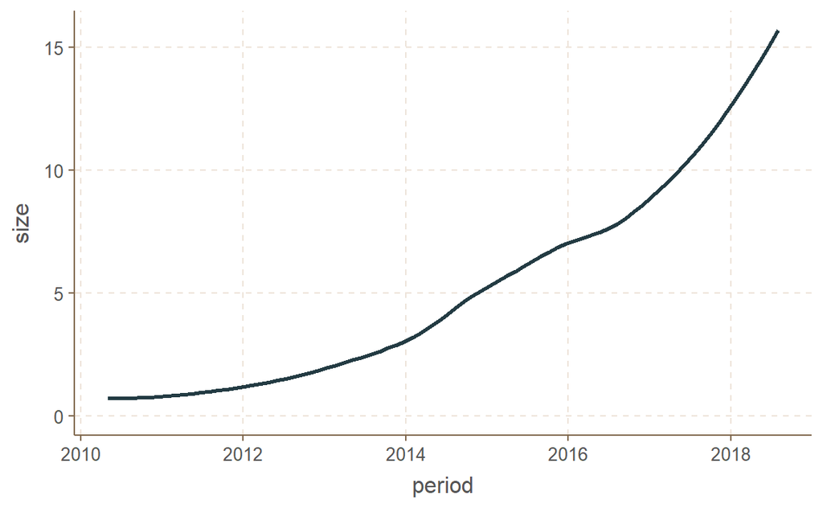

As above chart confirmed - apps was requiring successive more virtual memory. This trend was growing from the beginning of investigating period, but over the years it became more and more dynamic. Next let’s focus on common statistical indicators of dynamics to check in details this matter. I calculated median size by year, absolute growth with constant base, absolute growth with variable base and relative growth with constant base.

Basic statistical dynamic’s indicators

| year | size | abs_growth_const | abs_growth_vrbl | relative_growth_const |
| --- | --- | --- | --- | --- |
| 2011 | 3.35 | 0.00 | 0.00 | 0.00000 |
| 2012 | 6.40 | 3.05 | 3.05 | 91.04478 |
| 2013 | 7.60 | 4.25 | 1.20 | 126.86567 |
| 2014 | 6.95 | 3.60 | -0.65 | 107.46269 |
| 2015 | 6.30 | 2.95 | -0.65 | 88.05970 |
| 2016 | 8.90 | 5.55 | 2.60 | 165.67164 |
| 2017 | 9.80 | 6.45 | 0.90 | 192.53731 |
| 2018 | 17.00 | 13.65 | 7.20 | 407.46269 |

Relative dynamics plot by year

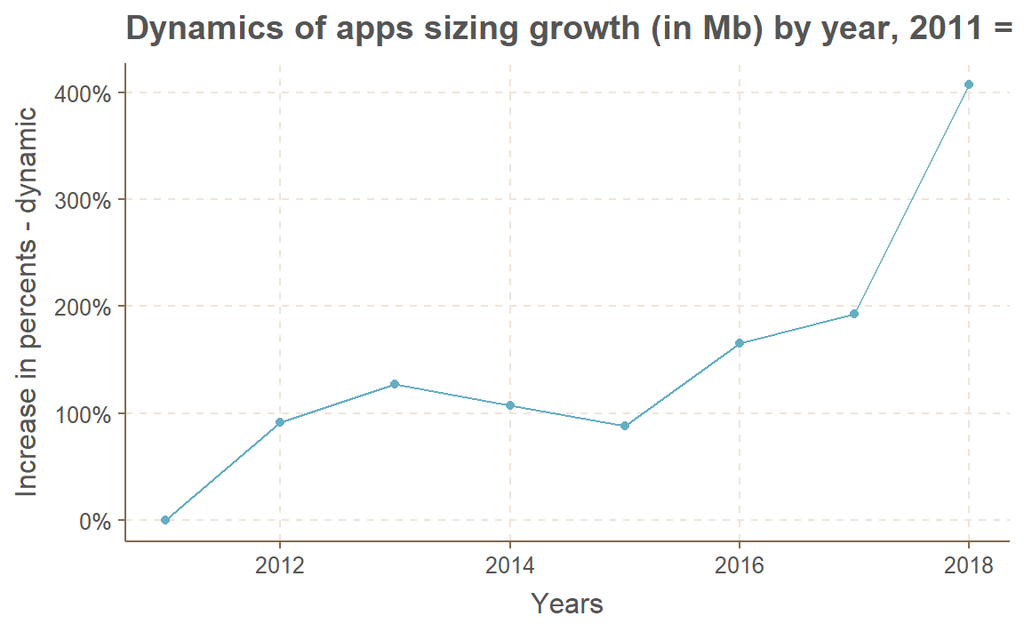

2018 apps required an average of more than 4 times more virtual memory than 2011.

And below - how does distribution of other indicator look on time range being researched.

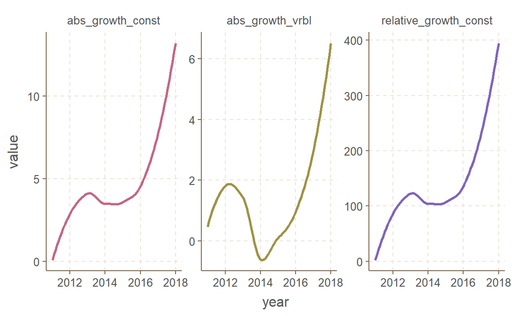

All of indicators measure the same, but differ in their sensitivity to change.

**Which type of apps requires more virtual space on device? Does it depend on type if app is paid or free?**

For answer this question, I present on charts below.

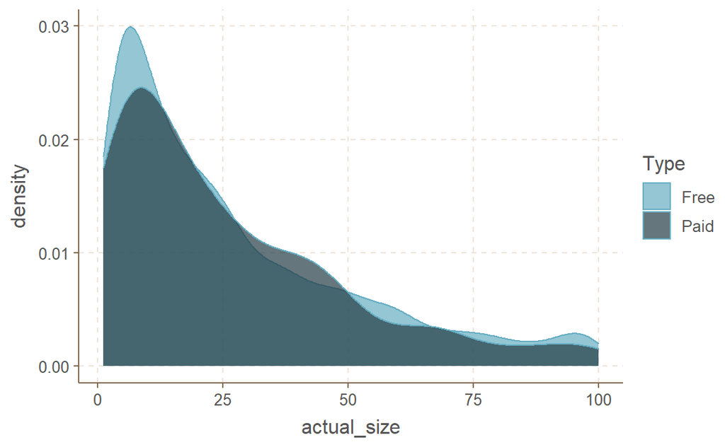

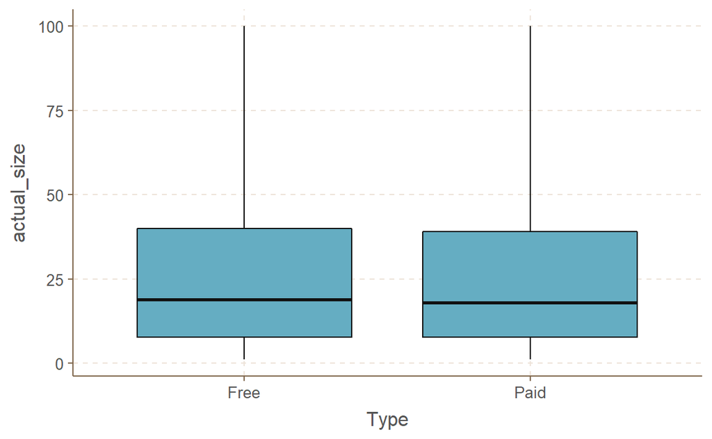

By charts, it seems to be no relationship between type and size of the apps. To confirm, have a look at the table where you can find basic statistical ratios:

Basic statistical indicators

| Type | min | Q1 | median | Q3 | max | mean | sd | n | missing |
| --- | --- | --- | --- | --- | --- | --- | --- | --- | --- |
| Free | 1.1 | 7.7 | 19 | 40 | 100 | 27.35071 | 24.72577 | 5021 | 0 |
| Paid | 1.1 | 7.8 | 18 | 39 | 100 | 25.93852 | 23.68507 | 257 | 0 |

As you can see, by median value, there is no significant relationship between sizing and type on the apps.

What about target groups? Let’s check if there any relationships exists.

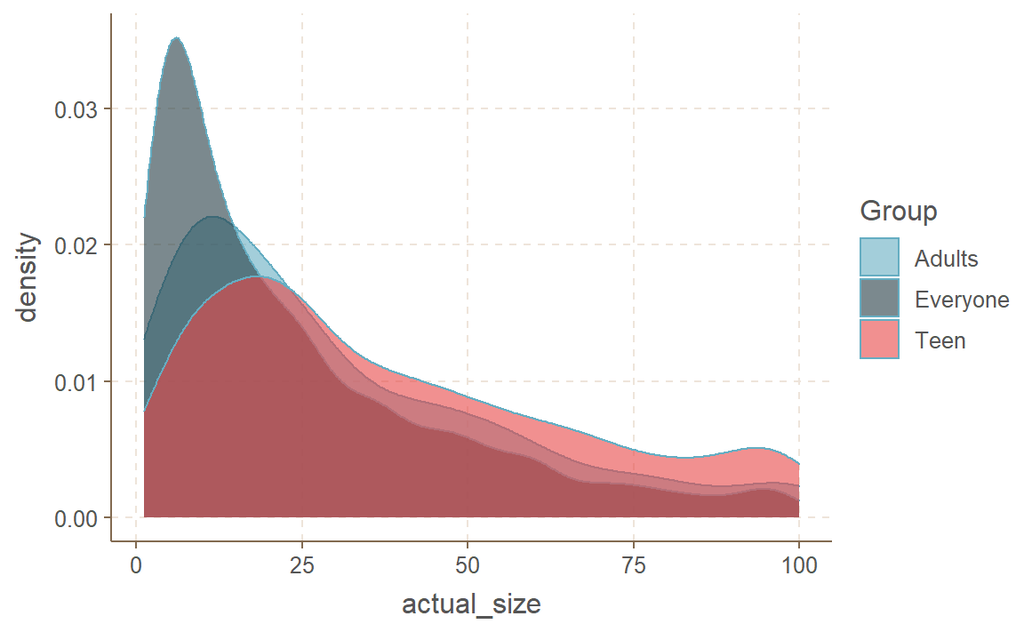

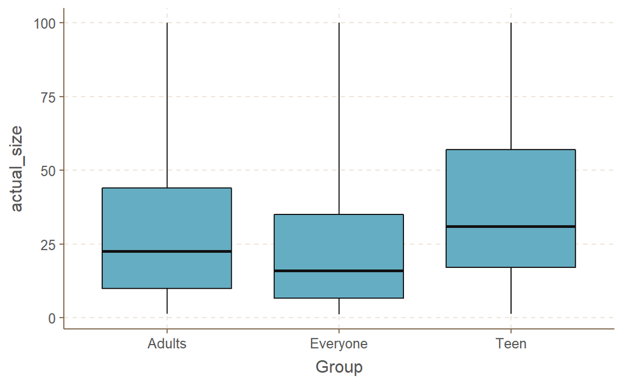

Basic statistical indicators

| Group | min | Q1 | median | Q3 | max | mean | sd | n | missing |
| --- | --- | --- | --- | --- | --- | --- | --- | --- | --- |
| Adults | 1.4 | 9.9 | 22.5 | 44 | 100 | 30.13264 | 25.35495 | 288 | 0 |
| Everyone | 1.1 | 6.6 | 16.0 | 35 | 100 | 24.26219 | 22.99576 | 3994 | 0 |
| Teen | 1.3 | 17.0 | 31.0 | 57 | 100 | 38.56697 | 27.48260 | 996 | 0 |

We are able to see visible relationship right here - applications for the youngest customers require the most space in mobile devices. As you might remember, the most numerous category among young people are games, and they usually take the most virtual storage.

To confirm above let’s have a look how much virtual memory do popular categories require.

Selecting categories

| Category | n | prop |
| --- | --- | --- |
| FAMILY | 1084 | 20.538083 |
| GAME | 867 | 16.426677 |
| TOOLS | 359 | 6.801819 |

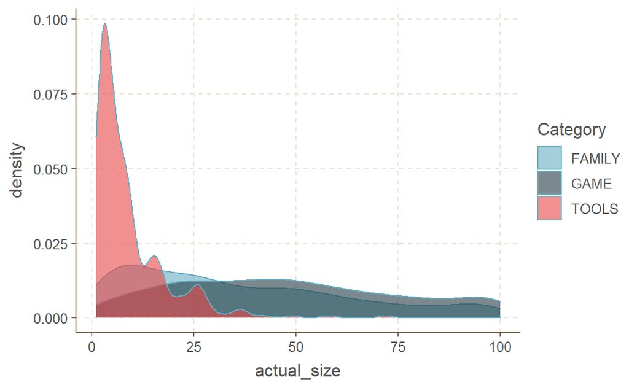

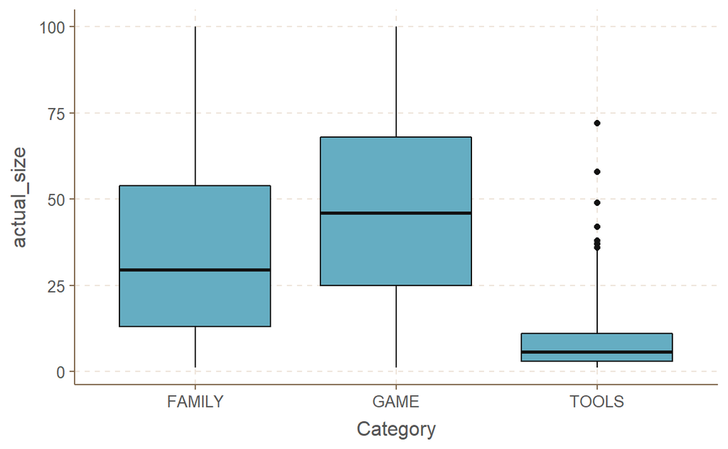

Basic statistical indicators

| Category | min | Q1 | median | Q3 | max | mean | sd | n | missing |
| --- | --- | --- | --- | --- | --- | --- | --- | --- | --- |
| FAMILY | 1.1 | 13 | 29.5 | 54 | 100 | 36.145941 | 27.28513 | 1084 | 0 |
| GAME | 1.1 | 25 | 46.0 | 68 | 100 | 47.750865 | 27.36064 | 867 | 0 |
| TOOLS | 1.1 | 3 | 5.8 | 11 | 72 | 8.980501 | 9.10688 | 359 | 0 |

Here the relationship is also very visible (because of obvious technical conditions), moreover, the hypothesis about games is also confirmed, they take the most places, so the group of young people clearly stands out from the rest when it comes to hardware requirements.